# Calssification in R

# Introduction

Machine learning is the fascinating field of building models to learn from data and then to predict unseen data which has shown more and more promising results.

Classification is the most widely used machine learning technique. The basic idea is to build a classifier which learns from training observations with discrete classes and then is applied to predict the outcome for new observations. There most common example we have seen everyday is probably the spam or junk mail filter in the email system which is telling you whether the email is a junk mail or not.

### Load the libraries

```r
library(mlbench)              # datasets
library(class)                # knn
library(caret)
library(e1071)                # svm
library(MASS)                 # lda
```

### Load the dataset

```r
apply(Ionosphere, 2, var)
```

```
NAs introduced by coercion
```

```
        V1         V2         V3         V4         V5         V6         V7
0.09681726 0.00000000 0.24771345 0.19486466 0.27025599 0.21234597 0.24270774
        V8         V9        V10        V11        V12        V13        V14
0.27118045 0.25711545 0.23411168 0.31752815 0.24484431 0.38711557 0.24489893
       V15        V16        V17        V18        V19        V20        V21
0.42618418 0.21010367 0.38194916 0.24677247 0.39221012 0.26943999 0.37189058
       V22        V23        V24        V25        V26        V27        V28
0.26849589 0.36453518 0.27821017 0.33460543 0.25856666 0.26646726 0.30252777
       V29        V30        V31        V32        V33        V34      Class
0.33164418 0.25803769 0.32659324 0.26375862 0.27317700 0.21933975         NA
```

## Training and test set split

We can’t use the train error to measure the performance of the model on the unseen data. One approach is called train/test split which will hold out a subset of data as the test set to estimate how well the generalization of the model. Another more robust approach is cross-validation which will divide the data set into `k` fold and each time it will hold out one fold for test and train withe rest. It gives you multiple estimate of out-of-sample errors.

It is important to shuffle the samples before the split. Generally we can split training and test set into 7/3.

```r
set.seed(1)
df <- Ionosphere[, -c(1, 2)]
ix_shuffled <- sample(1:nrow(df), size=nrow(df), replace=F)
ix_train <- ix_shuffled[1:round(0.7 * nrow(df))]
df_train <- df[ix_train, ]
df_test <- df[-ix_train, ]
```

Alternatively, we can utilize the createDataPartition function from caret library.

```r
ixTrain <- createDataPartition(df$Class, p=0.7)
```

## SVM (Support Vector Machines) model

The basic idea of SVM model is to find the hyperplane that can seperate the classes in the feature space while maximizing the margain (or gap) between classes. If the feature space can’t be separated by linear boundary, we can enlarge the feature space through kernel tricks (namely polynomial kernel, radial kernel, etc.) to make it linear separable. SVM model is implemented in the library e1071.

```r
library(e1071)
```

### SVM model with linear kernel

```r
svm_model1 <- svm(Class ~ ., data=df_train, kernel="linear", type="C-classification")
svm_pred1 <- predict(svm_model1, df_test)
```

### Model performance metrics

We define a function to obtain various performance metrics for the classification model. * Accuracy * Precision * Recall * F1 score

```r
classification_metrics <- function(truth, pred, pos_label=NULL) {
  if (length(unique(truth)) == 2 & is.null(pos_label)) {
    stop("pos_label must not NULL")
  }
  else if (length(unique(truth)) == 2) {
    conf <- table(truth, pred)
    acc <- sum(diag(conf)) / sum(conf)
    pos_ix <- which(colnames(conf) == pos_label)
    TP <- conf[pos_ix, pos_ix]
    TN <- conf[-pos_ix, -pos_ix]
    FP <- conf[-pos_ix, pos_ix]
    FN <- conf[pos_ix, -pos_ix]
    precision <- TP / (TP + FP)
    recall <- TP / (TP + FN)
    F1_score <- 2*TP / (2*TP + FP + FN)
    metrics <- list(accuracy=acc, precision=precision, recall=recall, F1_score=F1_score, TP=TP, TN=TN, FP=FP, FN=FN)
  }
}
```

```r
svm_metrics1 <- classification_metrics(df_test$Class, svm_pred1, pos_label="good")
cat(c("Accuracy:", round(svm_metrics1$accuracy, digits = 3)))
cat(c("Precision:", round(svm_metrics1$precision, digits = 3)))
cat(c("Recall:", round(svm_metrics1$recall, digits = 3)))
cat(c("F1 score:", round(svm_metrics1$F1_score, digits = 3)))
```

[output not shown]

### SVM model with polynomial kernel

```r
svm_model2 <- svm(Class ~ ., data=df_train, kernel="polynomial", type="C-classification")
svm_pred2 <- predict(svm_model2, df_test)
```

### Model performance metrics

```r
svm_metrics2 <- classification_metrics(df_test$Class, svm_pred2, pos_label="good")
cat(c("Accuracy:", round(svm_metrics2$accuracy, digits = 3)))
cat(c("Precision:", round(svm_metrics2$precision, digits = 3)))
cat(c("Recall:", round(svm_metrics2$recall, digits = 3)))
cat(c("F1 score:", round(svm_metrics2$F1_score, digits = 3)))
```

[output not shown]

### SVM model with RBF kernel

```r
svm_model3 <- svm(Class ~ ., data=df_train, kernel="radial", type="C-classification")
svm_pred3 <- predict(svm_model3, df_test)
```

### Model performance metrics

```r
svm_metrics3 <- classification_metrics(df_test$Class, svm_pred3, pos_label="good")
cat(c("Accuracy:", round(svm_metrics3$accuracy, digits = 3)))
cat(c("Precision:", round(svm_metrics3$precision, digits = 3)))
cat(c("Recall:", round(svm_metrics3$recall, digits = 3)))
cat(c("F1 score:", round(svm_metrics3$F1_score, digits = 3)))
```

[output not shown]

## kNN (k-Nearest Neighbours) model

kNN is an instance-based learning method, also knows as non-parametric lazy learning algorithm. It is because unlike most of the algorithms which are required to learn the weights (parameters) of the model during training process, kNN just stores the training samples and make prediction for unseen data by comparing them to the training set with a given distance metric.

```r
knn_pred1 <- knn(train=df_train[, -33], test=df_test[, -33], cl=df_train$Class, k=3)
```

### Model performance metrics

```r
knn_metrics1 <- classification_metrics(df_test$Class, knn_pred1, pos_label="good")
cat(c("Accuracy:", round(knn_metrics1$accuracy, digits = 3)))
cat(c("Precision:", round(knn_metrics1$precision, digits = 3)))
cat(c("Recall:", round(knn_metrics1$recall, digits = 3)))
cat(c("F1 score:", round(knn_metrics1$F1_score, digits = 3)))
```

[output not shown]

## Logistic Regression model

```r
lr_model1 <- glm(Class ~ ., data=df_train, family=binomial(link="logit"))
summary(lr_model1)
lr_pred1 <- predict(lr_model1, df_test, type="response")
lr_pred1 <- ifelse(lr_pred1 > 0.5, "good", "bad")
```

[output not shown]

### Model performance metrics

```r
lr_metrics1 <- classification_metrics(df_test$Class, lr_pred1, pos_label="good")
cat(c("Accuracy:", round(lr_metrics1$accuracy, digits = 3)))
cat(c("Precision:", round(lr_metrics1$precision, digits = 3)))
cat(c("Recall:", round(lr_metrics1$recall, digits = 3)))
cat(c("F1 score:", round(lr_metrics1$F1_score, digits = 3)))
```

[output not shown]

## LDA (Linear Discriminant Analysis) model

```r
lda_model1 <- lda(Class ~ ., data=df_train)
lda_pred1 <- predict(lda_model1, df_test, type="response")$class
```

### Model performance metrics

```r
lda_metrics1 <- classification_metrics(df_test$Class, lda_pred1, pos_label="good")
cat(c("Accuracy:", round(lda_metrics1$accuracy, digits = 3)))
cat(c("Precision:", round(lda_metrics1$precision, digits = 3)))
cat(c("Recall:", round(lda_metrics1$recall, digits = 3)))
cat(c("F1 score:", round(lda_metrics1$F1_score, digits = 3)))
```

[output not shown]

## Decision Tree model

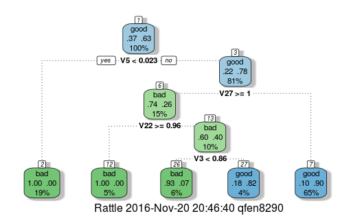

```r
library(rpart)
library(rattle)
library(RColorBrewer)
dt_model1 <- rpart(Class ~ ., data=df_train)
fancyRpartPlot(dt_model1)
```

```r
dt_pred1 <- predict(dt_model1, df_test, type="class")
```

### Model performance metrics

```r
dt_metrics1 <- classification_metrics(df_test$Class, dt_pred1, pos_label="good")
cat(c("Accuracy:", round(dt_metrics1$accuracy, digits = 3)))
```

```
Accuracy: 0.924
```

```r
cat(c("Precision:", round(dt_metrics1$precision, digits = 3)))
```

```
Precision: 0.897
```

```r
cat(c("Recall:", round(dt_metrics1$recall, digits = 3)))
```

```
Recall: 1
```

```r
cat(c("F1 score:", round(dt_metrics1$F1_score, digits = 3)))
```

```
F1 score: 0.946
```

## XGBoost model

```r
library(xgboost)
```

XGBoost only works with numeric vectors, so we need to convert the Class into numeric first.

```r
df_train_label <- df_train$Class == "good"
df_train_label
```

[output not shown]

```r
xgb_model1 <- xgboost(data=as.matrix(df_train[, -33]), label=df_train_label, nrounds=20, objective="binary:logistic", eta=0.3, max_depth=6)
```

### Model performance metrics

```r
xgb_metrics1 <- classification_metrics(df_test$Class, xgb_pred1, pos_label="good")
cat(c("Accuracy:", round(xgb_metrics1$accuracy, digits = 3)))
```

```
Accuracy: 0.924
```

```r
cat(c("Precision:", round(xgb_metrics1$precision, digits = 3)))
```

```
Precision: 0.919
```

```r
cat(c("Recall:", round(xgb_metrics1$recall, digits = 3)))
```

```
Recall: 0.971
```

```r
cat(c("F1 score:", round(xgb_metrics1$F1_score, digits = 3)))
```

```
F1 score: 0.944
```

### Feature importance

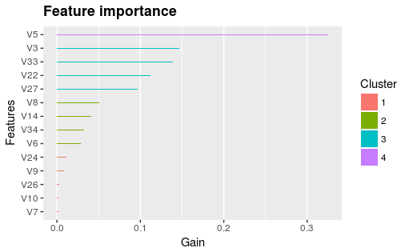

## Random Forest

```r
library(randomForest)
```

### Model performance metrics

```r
rf_metrics1 <- classification_metrics(df_test$Class, rf_pred1, pos_label="good")
cat(c("Accuracy:", round(rf_metrics1$accuracy, digits = 3)))
```

```
Accuracy: 0.943
```

```r
cat(c("Precision:", round(rf_metrics1$precision, digits = 3)))
```

```
Precision: 0.957
```

```r
cat(c("Recall:", round(rf_metrics1$recall, digits = 3)))
```

```
Recall: 0.957
```

```r
cat(c("F1 score:", round(rf_metrics1$F1_score, digits = 3)))
```

```
F1 score: 0.957
```

# ROC (Receiver Operator Characteristic) Curve

ROC is a very powerful performance measurement for binary classification. Good classifiers have big area under the curve (AUC).

```r
library(ROCR)
```

## Compare the ROC for different classifiers

[figure not shown]